# Star-data-analysis

Star Li

4/12/2020

```r
lamanno_brain_es = LaMannoBrainData('human-es')
```

```
## snapshotDate(): 2019-10-22
```

```
## see ?scRNAseq and browseVignettes('scRNAseq') for documentation
```

```
## loading from cache
```

```
## see ?scRNAseq and browseVignettes('scRNAseq') for documentation
```

```
## loading from cache
```

```r
lamanno_brain_es
```

```
## class: SingleCellExperiment
## dim: 18538 1715
## metadata(0):
## assays(1): counts
## rownames(18538): WASH7P_p1 LINC01002_loc4 ... IL9R_loc1 DDX11L16_loc1
## rowData names(0):
## colnames(1715): 1772122_301_C02 1772122_180_E05 ... 1772122_310_H11
##   1772122_311_H02
## colData names(3): Cell_ID Cell_type Timepoint
## reducedDimNames(0):
## spikeNames(0):
## altExpNames(0):
```

```r
count_mat = counts(lamanno_brain_es)
```

### Step One: Quality Control

We are primarily concerned with the following metrics.

1. library (cell) size: the library size is the sum across all features for a given cell. Small library size might indicate low quality as the RNA has been lost at some point during library preparation, either due to cell lysis or inefficient cDNA capture and amplification.

Plotting the distribution of library sizes for all cells.

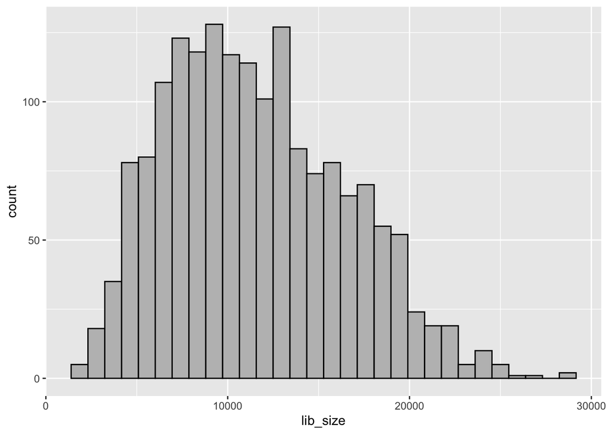

```r
lib_sizes = colSums(count_mat)

count_dist = ggplot(data.frame(lib_size=lib_sizes), aes(x=lib_size)) + geom_histogram(color="black", fill="grey")

count_dist
```

```r
summary(lib_sizes)
```

```
##    Min. 1st Qu.  Median    Mean 3rd Qu.    Max.
##    2111    7714   11072   11571   15041   28960
```

2. The number of expressed features in each cell is defined as the number of endogenous genes with non-zero counts for that cell. Any cell with very few expressed genes is likely to be of poor quality as the diverse transcript population has not been successfully captured.

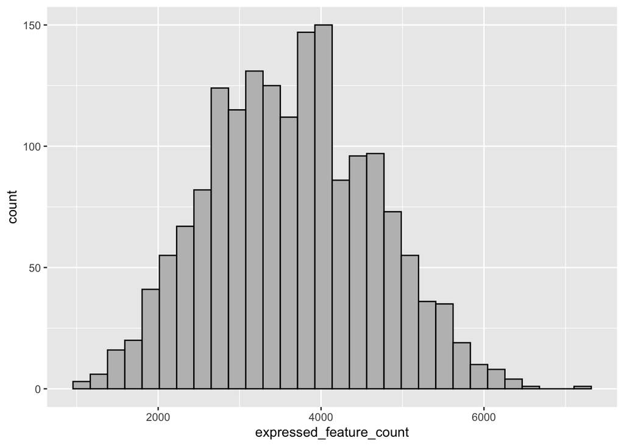

```r
expressed_feature = apply(count_mat, 2, function(col) sum(col > 0))

ggplot(data.frame(expressed_feature_count=expressed_feature), aes(x=expressed_feature_count)) + geom_histogram(color="black", fill="grey")
```

```r
summary(expressed_feature)
```

```
##    Min. 1st Qu.  Median    Mean 3rd Qu.    Max.
##     959    2882    3635    3641    4357    7110
```

Since our chosen dataset doesn’t have genes from spike-in transcripts or mitochondrial genome, there are fewer metric to look at when deciding the quality of the cells. So the returned value from `addPerCellQC` method has fewer columns.

```r
lamanno_brain_es = addPerCellQC(lamanno_brain_es)
colnames(colData(lamanno_brain_es))
```

```
##  [1] "Cell_ID"         "Cell_type"       "Timepoint"       "sum"
##  [5] "detected"        "percent_top_50"  "percent_top_100" "percent_top_200"
##  [9] "percent_top_500" "total"
```

```r
# total column is identical with sum, so we should remove it
colData(lamanno_brain_es)$total = NULL
```

Method 1: Fixed Threshold

We have observed the distribution of library sizes and expressed features (counts). So we may manually select a threshold for identifying low quality cells.

```r
# fixed quality control
df = colData(lamanno_brain_es)

qc.lib = df$sum < 5000
qc.express = df$detected < 2000
discard = qc.lib | qc.express

DataFrame(LibSize=sum(qc.lib), Express=sum(qc.express),
    Total=sum(discard))
```

```
## DataFrame with 1 row and 3 columns
##     LibSize   Express     Total
##   <integer> <integer> <integer>
## 1       127        83       134
```

Method 2: Adaptive Threshold

```r
# identify the outliers
qc.lib2 <- isOutlier(df$sum, log=TRUE, type="lower")
qc.express2 <- isOutlier(df$detected, log=TRUE, type="lower")

attr(qc.lib2, "thresholds")
```

```
##    lower   higher
## 2580.195      Inf
```

```r
attr(qc.express2, "thresholds")
```

```
##   lower  higher
## 1471.01     Inf
```

```r
discard2 = qc.lib2 | qc.express2

DataFrame(LibSize=sum(qc.lib2), Express=sum(qc.express2),
    Total=sum(discard2))
```

```
## DataFrame with 1 row and 3 columns
##     LibSize   Express     Total
##   <integer> <integer> <integer>
## 1         7        17        17
```

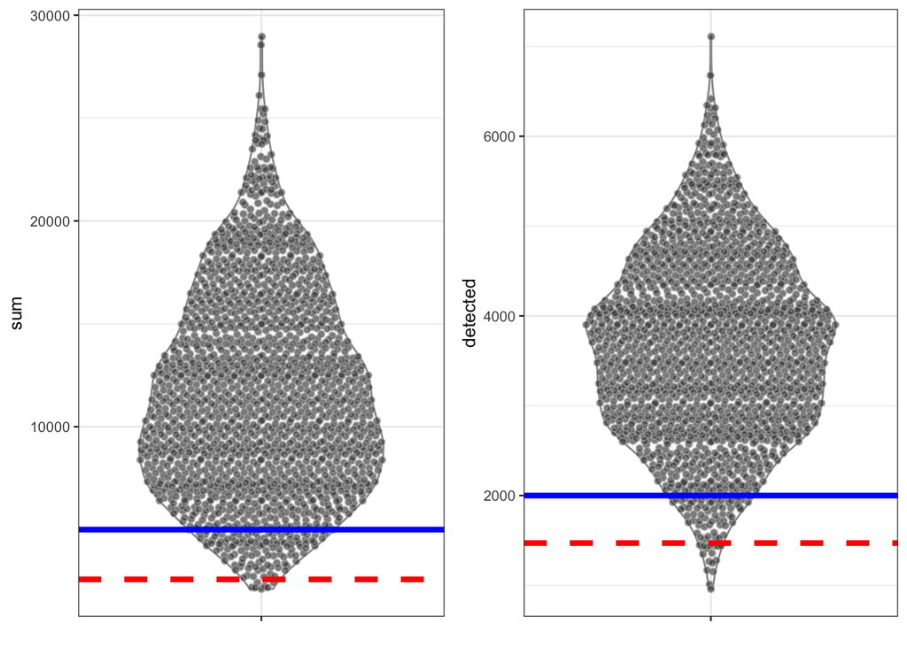

```r
lib2_thresh = attr(qc.lib2, "thresholds")[1]
express2_thresh = attr(qc.express2, "thresholds")[1]

qc.plot1 = plotColData(lamanno_brain_es, y="sum") + geom_hline(yintercept = lib2_thresh, colour = "red", size = 1.5, linetype = "dashed") + geom_hline(yintercept = 5000, colour = "blue", size = 1.5)

qc.plot2 = plotColData(lamanno_brain_es, y="detected") + geom_hline(yintercept = express2_thresh, colour = "red", size = 1.5, linetype = "dashed") + geom_hline(yintercept = 2000, colour = "blue", size = 1.5)

gridExtra::grid.arrange(qc.plot1, qc.plot2, ncol=2)
```

Finally we will remove the `low quality` cells from the object.

```r
lamanno_brain_es = lamanno_brain_es[, !discard2]
```

### Step2: Normalization

This step looks somewhat straightforward to our dataset without any spike-in adding complexity.

```r
lib_sf = librarySizeFactors(lamanno_brain_es)
summary(lib_sf)
```

```
##    Min. 1st Qu.  Median    Mean 3rd Qu.    Max.
##  0.2587  0.6702  0.9555  1.0000  1.2924  2.4839
```

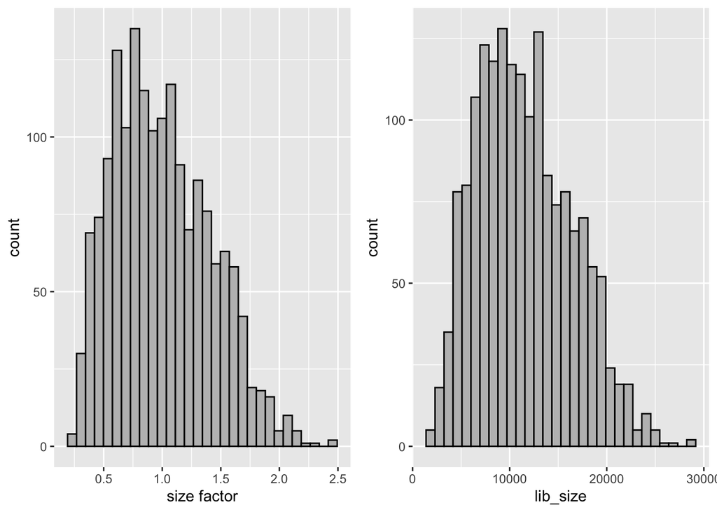

```r
lib_sizes = colSums(count_mat)
count_dist = ggplot(data.frame(lib_size=lib_sizes), aes(x=lib_size)) + geom_histogram(color="black", fill="grey")

sz_dist = ggplot() + geom_histogram(aes(x=lib_sf), color="black", fill="grey") + xlab("size factor")

gridExtra::grid.arrange(sz_dist, count_dist, ncol=2)
```

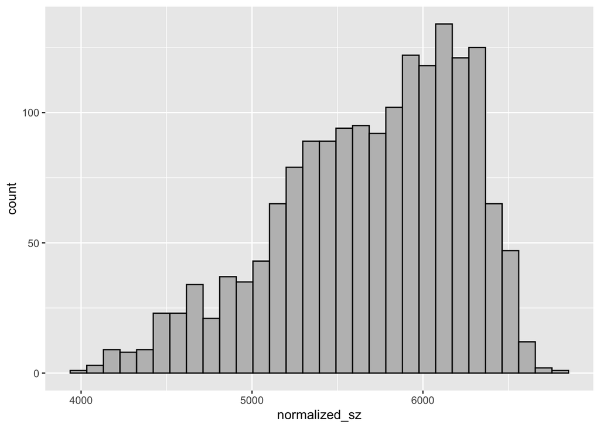

```r
set.seed(2020)
clust = quickCluster(lamanno_brain_es)
lamanno_brain_es = computeSumFactors(lamanno_brain_es, cluster=clust, min.mean=0.1)
lamanno_brain_es = logNormCounts(lamanno_brain_es)

normalized_sz = colSums(logcounts(lamanno_brain_es))
ggplot() + geom_histogram(aes(x=normalized_sz), color="black", fill="grey")
```

### Step3: Feature Selection

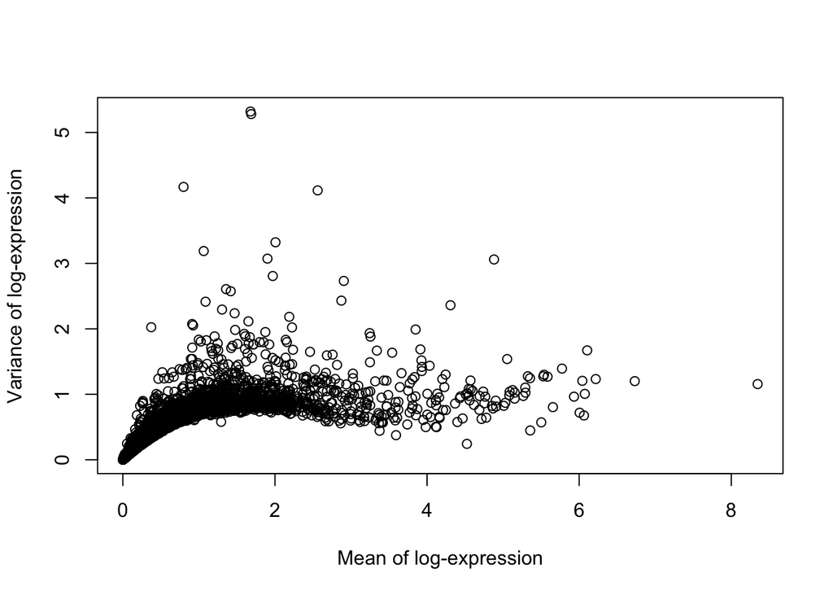

```r
mean_var <- modelGeneVar(lamanno_brain_es)

# Visualizing the fit:
fit.meanvar <- metadata(mean_var)
plot(fit.meanvar$mean, fit.meanvar$var, xlab="Mean of log-expression",
    ylab="Variance of log-expression")
```

```r
head(mean_var[order(mean_var$bio, decreasing=TRUE),])
```

```
## DataFrame with 6 rows and 6 columns
##                           mean            total              tech
##                      <numeric>        <numeric>         <numeric>
## SNAR-B1_loc1  1.67829429993204 5.31981919117145 0.903245123072221
## SNAR-B1_loc2  1.68744820523851 5.28079655919654 0.903985448586203
## TTR          0.797829457032653 4.16774049074981 0.646243920002417
## CRABP1        2.56147467763027 4.11470469771329 0.887348876516494
## STMN2         1.06306852101687 3.18795580210562 0.770894608694267
## PRTG          2.00678034309028 3.32202470268495 0.915615384858741
##                           bio               p.value                   FDR
##                     <numeric>             <numeric>             <numeric>
## SNAR-B1_loc1 4.41657406809923 5.12933150289624e-152 4.75437737003452e-148
## SNAR-B1_loc2 4.37681111061034 4.30494672550647e-149 2.66017007991463e-145
## TTR           3.5214965707474 3.15884797650961e-188 5.85587237885352e-184
## CRABP1       3.22735582119679  4.07273208741154e-85   1.5100061487287e-81
## STMN2        2.41706119341135  8.21819444247368e-64  2.53914814290962e-60
## PRTG         2.40640931782621  1.84783300485635e-45  4.89358974914671e-42
```

```r
chosen = getTopHVGs(mean_var, prop=0.1)
str(chosen)
```

```
##  chr [1:538] "SNAR-B1_loc1" "SNAR-B1_loc2" "TTR" "CRABP1" "STMN2" "PRTG" ...
```

```r
set.seed(2020)
lamanno_brain_es = runPCA(lamanno_brain_es, subset_row=chosen)
lamanno_brain_es = runUMAP(lamanno_brain_es, dimred = 'PCA', external_neighbors=TRUE, subset_row=chosen)
lamanno_brain_es = runTSNE(lamanno_brain_es, dimred = 'PCA', perplexity = 20, subset_row=chosen)
```